# Introduction to Neural Networks: SVHN Digit Recognition

## Model Improvement: Neural Network model with Dropout

```python
BackendClearSession()
```

```python
#Initializing the neural network
model_3 = Sequential()

## Add input layer with 32 neurons and relu as activation function
model_3.add(Dense(32, activation='relu', input_dim = X_train.shape[1]))

## Add dropout with dropout_rate= 0.2
model_3.add(Dropout(0.2))
## Add Hiden layer with 32 neurons and relu as activation function
model_3.add(Dense(32, activation='relu'))

## Add dropout with dropout_rate= 0.1
model_3.add(Dropout(0.1))
## Add Hiden layer with 8 neurons and relu as activation function
model_3.add(Dense(8, activation='relu'))

## Add Output layer with softmax as activation function with 10 neurons (Predicting 10 classes)
model_3.add(Dense(10, activation = 'softmax'))
```

```python
model_3.summary()
```

```
Model: "sequential"
```

```
┏━━━━━━━━━━━━━━━━━━━━━━━━━━━━━━━━━┳━━━━━━━━━━━━━━━━━━━━━━━━┳━━━━━━━━━━━━━━━┓
┃ Layer (type)                    ┃ Output Shape           ┃       Param # ┃
┡━━━━━━━━━━━━━━━━━━━━━━━━━━━━━━━━━╇━━━━━━━━━━━━━━━━━━━━━━━━╇━━━━━━━━━━━━━━━┩
│ dense (Dense)                   │ (None, 32)             │        32,800 │
├─────────────────────────────────┼────────────────────────┼───────────────┤
│ dropout (Dropout)               │ (None, 32)             │             0 │
├─────────────────────────────────┼────────────────────────┼───────────────┤
│ dense_1 (Dense)                 │ (None, 32)             │         1,056 │
├─────────────────────────────────┼────────────────────────┼───────────────┤
│ dropout_1 (Dropout)             │ (None, 32)             │             0 │
├─────────────────────────────────┼────────────────────────┼───────────────┤
│ dense_2 (Dense)                 │ (None, 8)              │           264 │
├─────────────────────────────────┼────────────────────────┼───────────────┤
│ dense_3 (Dense)                 │ (None, 10)             │            90 │
└─────────────────────────────────┴────────────────────────┴───────────────┘
```

```
 Total params: 34,210 (133.63 KB)
```

```
 Trainable params: 34,210 (133.63 KB)
```

```
 Non-trainable params: 0 (0.00 B)
```

```python
# Initialize ANN with Adam optimizer
optimizer = tf.keras.optimizers.Adam()

## Compile Model with categorical cross entropy as loss function and accuracy as metrics
model_3.compile(loss = 'categorical_crossentropy' , optimizer=optimizer, metrics=['accuracy', 'recall'])
```

```python
## Fit Model on X_train and y_train_en data for 100 epochs
batch_size = 32

start = time.time()
history_3 = model_3.fit(X_train, y_train_en, validation_split=0.2, epochs=epochs, batch_size=batch_size, verbose=1)
end = time.time()
```

```
1050/1050 ━━━━━━━━━━━━━━━━━━━━ 7s 5ms/step - accuracy: 0.0977 - loss: 2.3036 - recall: 0.0000e+00 - val_accuracy: 0.0974 - val_loss: 2.3030 - val_recall: 0.0000e+00
1050/1050 ━━━━━━━━━━━━━━━━━━━━ 9s 4ms/step - accuracy: 0.0990 - loss: 2.3031 - recall: 0.0000e+00 - val_accuracy: 0.0974 - val_loss: 2.3030 - val_recall: 0.0000e+00
1050/1050 ━━━━━━━━━━━━━━━━━━━━ 7s 5ms/step - accuracy: 0.0996 - loss: 2.3029 - recall: 0.0000e+00 - val_accuracy: 0.0974 - val_loss: 2.3030 - val_recall: 0.0000e+00
1050/1050 ━━━━━━━━━━━━━━━━━━━━ 9s 4ms/step - accuracy: 0.0996 - loss: 2.3029 - recall: 0.0000e+00 - val_accuracy: 0.0974 - val_loss: 2.3030 - val_recall: 0.0000e+00
1050/1050 ━━━━━━━━━━━━━━━━━━━━ 5s 5ms/step - accuracy: 0.0996 - loss: 2.3029 - recall: 0.0000e+00 - val_accuracy: 0.0974 - val_loss: 2.3030 - val_recall: 0.0000e+00
1050/1050 ━━━━━━━━━━━━━━━━━━━━ 9s 4ms/step - accuracy: 0.0996 - loss: 2.3029 - recall: 0.0000e+00 - val_accuracy: 0.0974 - val_loss: 2.3030 - val_recall: 0.0000e+00
1050/1050 ━━━━━━━━━━━━━━━━━━━━ 6s 4ms/step - accuracy: 0.0996 - loss: 2.3029 - recall: 0.0000e+00 - val_accuracy: 0.0974 - val_loss: 2.3030 - val_recall: 0.0000e+00
1050/1050 ━━━━━━━━━━━━━━━━━━━━ 5s 4ms/step - accuracy: 0.0996 - loss: 2.3029 - recall: 0.0000e+00 - val_accuracy: 0.0974 - val_loss: 2.3030 - val_recall: 0.0000e+00
1050/1050 ━━━━━━━━━━━━━━━━━━━━ 7s 5ms/step - accuracy: 0.0996 - loss: 2.3029 - recall: 0.0000e+00 - val_accuracy: 0.0974 - val_loss: 2.3030 - val_recall: 0.0000e+00
1050/1050 ━━━━━━━━━━━━━━━━━━━━ 9s 4ms/step - accuracy: 0.0996 - loss: 2.3029 - recall: 0.0000e+00 - val_accuracy: 0.0974 - val_loss: 2.3030 - val_recall: 0.0000e+00
1050/1050 ━━━━━━━━━━━━━━━━━━━━ 7s 5ms/step - accuracy: 0.0996 - loss: 2.3029 - recall: 0.0000e+00 - val_accuracy: 0.0974 - val_loss: 2.3030 - val_recall: 0.0000e+00
1050/1050 ━━━━━━━━━━━━━━━━━━━━ 4s 4ms/step - accuracy: 0.0996 - loss: 2.3029 - recall: 0.0000e+00 - val_accuracy: 0.0974 - val_loss: 2.3030 - val_recall: 0.0000e+00
1050/1050 ━━━━━━━━━━━━━━━━━━━━ 4s 4ms/step - accuracy: 0.0996 - loss: 2.3029 - recall: 0.0000e+00 - val_accuracy: 0.0974 - val_loss: 2.3030 - val_recall: 0.0000e+00
1050/1050 ━━━━━━━━━━━━━━━━━━━━ 6s 5ms/step - accuracy: 0.0996 - loss: 2.3029 - recall: 0.0000e+00 - val_accuracy: 0.0974 - val_loss: 2.3030 - val_recall: 0.0000e+00
1050/1050 ━━━━━━━━━━━━━━━━━━━━ 4s 4ms/step - accuracy: 0.0996 - loss: 2.3029 - recall: 0.0000e+00 - val_accuracy: 0.0974 - val_loss: 2.3030 - val_recall: 0.0000e+00
1050/1050 ━━━━━━━━━━━━━━━━━━━━ 4s 4ms/step - accuracy: 0.0996 - loss: 2.3029 - recall: 0.0000e+00 - val_accuracy: 0.0974 - val_loss: 2.3030 - val_recall: 0.0000e+00
1050/1050 ━━━━━━━━━━━━━━━━━━━━ 5s 5ms/step - accuracy: 0.0996 - loss: 2.3029 - recall: 0.0000e+00 - val_accuracy: 0.0974 - val_loss: 2.3030 - val_recall: 0.0000e+00
1050/1050 ━━━━━━━━━━━━━━━━━━━━ 9s 4ms/step - accuracy: 0.0996 - loss: 2.3029 - recall: 0.0000e+00 - val_accuracy: 0.0974 - val_loss: 2.3030 - val_recall: 0.0000e+00
1050/1050 ━━━━━━━━━━━━━━━━━━━━ 6s 5ms/step - accuracy: 0.0996 - loss: 2.3029 - recall: 0.0000e+00 - val_accuracy: 0.0974 - val_loss: 2.3030 - val_recall: 0.0000e+00
1050/1050 ━━━━━━━━━━━━━━━━━━━━ 4s 4ms/step - accuracy: 0.0996 - loss: 2.3029 - recall: 0.0000e+00 - val_accuracy: 0.0974 - val_loss: 2.3030 - val_recall: 0.0000e+00
1050/1050 ━━━━━━━━━━━━━━━━━━━━ 5s 4ms/step - accuracy: 0.0996 - loss: 2.3029 - recall: 0.0000e+00 - val_accuracy: 0.0974 - val_loss: 2.3030 - val_recall: 0.0000e+00
1050/1050 ━━━━━━━━━━━━━━━━━━━━ 5s 5ms/step - accuracy: 0.0996 - loss: 2.3029 - recall: 0.0000e+00 - val_accuracy: 0.0974 - val_loss: 2.3030 - val_recall: 0.0000e+00
1050/1050 ━━━━━━━━━━━━━━━━━━━━ 4s 4ms/step - accuracy: 0.0996 - loss: 2.3029 - recall: 0.0000e+00 - val_accuracy: 0.0974 - val_loss: 2.3030 - val_recall: 0.0000e+00
1050/1050 ━━━━━━━━━━━━━━━━━━━━ 6s 5ms/step - accuracy: 0.0996 - loss: 2.3029 - recall: 0.0000e+00 - val_accuracy: 0.0974 - val_loss: 2.3030 - val_recall: 0.0000e+00
1050/1050 ━━━━━━━━━━━━━━━━━━━━ 5s 4ms/step - accuracy: 0.0996 - loss: 2.3029 - recall: 0.0000e+00 - val_accuracy: 0.0974 - val_loss: 2.3030 - val_recall: 0.0000e+00
1050/1050 ━━━━━━━━━━━━━━━━━━━━ 4s 4ms/step - accuracy: 0.0996 - loss: 2.3029 - recall: 0.0000e+00 - val_accuracy: 0.0974 - val_loss: 2.3030 - val_recall: 0.0000e+00
```

[output cut: 74 more lines]

```python
print("Time taken in seconds ",end-start)
```

```
Time taken in seconds  597.0111558437347
```

**Loss Function**

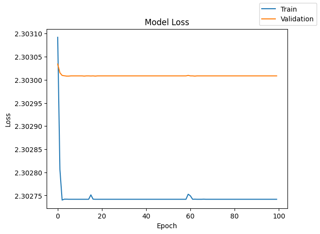

```python
plot(history_3,'loss')
```

**Recall**

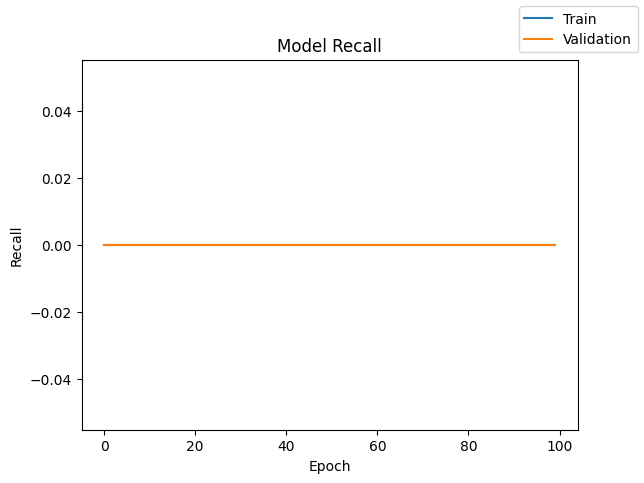

```python
plot(history_3,'recall')
```

```python
model_3_train_perf = model_performance_classification(model_3, X_train, y_train_en)
model_3_train_perf
```

```
1313/1313 ━━━━━━━━━━━━━━━━━━━━ 2s 1ms/step
```

|  | Accuracy | Recall | Precision | F1 Score |
| --- | --- | --- | --- | --- |
| 0 | 0.100762 | 0.100762 | 0.010153 | 0.018447 |

```python
model_3_test_perf = model_performance_classification(model_3, X_test, y_test_en)
model_3_test_perf
```

```
563/563 ━━━━━━━━━━━━━━━━━━━━ 1s 2ms/step
```

|  | Accuracy | Recall | Precision | F1 Score |
| --- | --- | --- | --- | --- |
| 0 | 0.098222 | 0.098222 | 0.009648 | 0.017569 |

```python
save_recall_score(model_3, "NN with Dropout")
```

```
1313/1313 ━━━━━━━━━━━━━━━━━━━━ 2s 1ms/step
563/563 ━━━━━━━━━━━━━━━━━━━━ 1s 1ms/step
```

**Classification Report**

```python
## Predict Model on X_train
y_pred3 = model_3.predict(X_train)

## Predict y_pred3 using argmax
y_pred3_argmax = np.argmax(y_pred3, axis=1)

## Classification report for train data
cr = metrics.classification_report(y_train_true_argmax, y_pred3_argmax)
print(cr)
```

```
1313/1313 ━━━━━━━━━━━━━━━━━━━━ 3s 2ms/step
              precision    recall  f1-score   support

           0       0.00      0.00      0.00      4186
           1       0.00      0.00      0.00      4172
           2       0.00      0.00      0.00      4197
           3       0.00      0.00      0.00      4281
           4       0.00      0.00      0.00      4188
           5       0.10      1.00      0.18      4232
           6       0.00      0.00      0.00      4168
           7       0.00      0.00      0.00      4192
           8       0.00      0.00      0.00      4188
           9       0.00      0.00      0.00      4196

    accuracy                           0.10     42000
   macro avg       0.01      0.10      0.02     42000
weighted avg       0.01      0.10      0.02     42000
```

```python
## Predict Model on X_test
y_pred3 = model_3.predict(X_test)

## Predict y_pred3 using argmax
y_pred3_argmax = np.argmax(y_pred3, axis=1)

## Classification report for test data on y_test_true_argmax and y_pred3_argmax
cr = metrics.classification_report(y_test_true_argmax, y_pred3_argmax)
print(cr)
```

```
563/563 ━━━━━━━━━━━━━━━━━━━━ 1s 1ms/step
              precision    recall  f1-score   support

           0       0.00      0.00      0.00      1814
           1       0.00      0.00      0.00      1828
           2       0.00      0.00      0.00      1803
           3       0.00      0.00      0.00      1719
           4       0.00      0.00      0.00      1812
           5       0.10      1.00      0.18      1768
           6       0.00      0.00      0.00      1832
           7       0.00      0.00      0.00      1808
           8       0.00      0.00      0.00      1812
           9       0.00      0.00      0.00      1804

    accuracy                           0.10     18000
   macro avg       0.01      0.10      0.02     18000
weighted avg       0.01      0.10      0.02     18000
```

**Confusion Matrix**

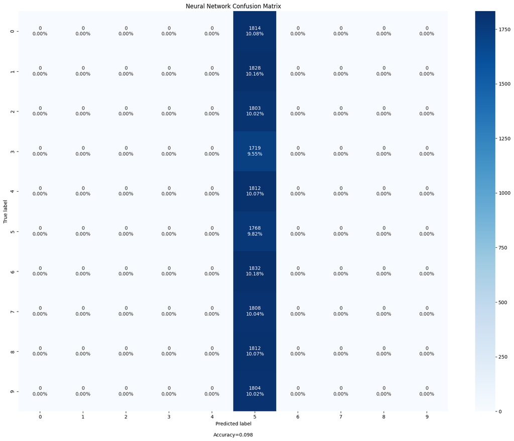

```python
## Plot Confusion Matrix
cm3 = confusion_matrix(y_test_true_argmax, y_pred3_argmax)
make_confusion_matrix(cm3, cmap='Blues', title='Neural Network Confusion Matrix')
plt.show()
```

# Model Improvement: Neural Network model with Batch Normalization

```python
BackendClearSession()
```

```python
#Initializing the neural network
model_4 = Sequential()

## Add input layer with 32 neurons and relu as activation function
model_4.add(Dense(32, activation='relu', input_dim = X_train.shape[1]))

# Add Batch Normalization
model_4.add(BatchNormalization())

## Add Hiden layer with 8 neurons and relu as activation function
model_4.add(Dense(8, activation='relu'))

# Add Batch Normalization
model_4.add(BatchNormalization())

## Add Output layer with sigmoid as activation function with 10 neurons (Predicting 10 classes)
model_4.add(Dense(10, activation = 'sigmoid'))
```

```python
model_4.summary()
```

```
Model: "sequential"
```

```
┏━━━━━━━━━━━━━━━━━━━━━━━━━━━━━━━━━┳━━━━━━━━━━━━━━━━━━━━━━━━┳━━━━━━━━━━━━━━━┓
┃ Layer (type)                    ┃ Output Shape           ┃       Param # ┃
┡━━━━━━━━━━━━━━━━━━━━━━━━━━━━━━━━━╇━━━━━━━━━━━━━━━━━━━━━━━━╇━━━━━━━━━━━━━━━┩
│ dense (Dense)                   │ (None, 32)             │        32,800 │
├─────────────────────────────────┼────────────────────────┼───────────────┤
│ batch_normalization             │ (None, 32)             │           128 │
│ (BatchNormalization)            │                        │               │
├─────────────────────────────────┼────────────────────────┼───────────────┤
│ dense_1 (Dense)                 │ (None, 8)              │           264 │
├─────────────────────────────────┼────────────────────────┼───────────────┤
│ batch_normalization_1           │ (None, 8)              │            32 │
│ (BatchNormalization)            │                        │               │
├─────────────────────────────────┼────────────────────────┼───────────────┤
│ dense_2 (Dense)                 │ (None, 10)             │            90 │
└─────────────────────────────────┴────────────────────────┴───────────────┘
```

```
 Total params: 33,314 (130.13 KB)
```

```
 Trainable params: 33,234 (129.82 KB)
```

```
 Non-trainable params: 80 (320.00 B)
```

```python
# Defining Adam as the optimizer to be used
optimizer = tf.keras.optimizers.Adam()

## Compile Model with categorical cross entropy as loss function
model_4.compile(loss='categorical_crossentropy', optimizer=optimizer, metrics=['accuracy', 'recall'])
```

```python
## Fit Model on X_train and y_train_en data for 100 epochs
start = time.time()
history_4 = model_4.fit(X_train, y_train_en, validation_split=0.2, epochs=epochs, batch_size=batch_size, verbose=1)
end = time.time()
```

```
1050/1050 ━━━━━━━━━━━━━━━━━━━━ 7s 4ms/step - accuracy: 0.1796 - loss: 2.2586 - recall: 0.6516 - val_accuracy: 0.2544 - val_loss: 2.1019 - val_recall: 0.6399
1050/1050 ━━━━━━━━━━━━━━━━━━━━ 6s 5ms/step - accuracy: 0.3481 - loss: 1.8129 - recall: 0.8591 - val_accuracy: 0.3152 - val_loss: 1.8514 - val_recall: 0.8188
1050/1050 ━━━━━━━━━━━━━━━━━━━━ 10s 5ms/step - accuracy: 0.4038 - loss: 1.6668 - recall: 0.8896 - val_accuracy: 0.4188 - val_loss: 1.6255 - val_recall: 0.8738
1050/1050 ━━━━━━━━━━━━━━━━━━━━ 5s 4ms/step - accuracy: 0.4256 - loss: 1.6021 - recall: 0.8972 - val_accuracy: 0.4423 - val_loss: 1.5930 - val_recall: 0.8706
1050/1050 ━━━━━━━━━━━━━━━━━━━━ 5s 4ms/step - accuracy: 0.4461 - loss: 1.5570 - recall: 0.9022 - val_accuracy: 0.4070 - val_loss: 1.7344 - val_recall: 0.8460
1050/1050 ━━━━━━━━━━━━━━━━━━━━ 7s 5ms/step - accuracy: 0.4639 - loss: 1.5220 - recall: 0.9058 - val_accuracy: 0.4419 - val_loss: 1.6474 - val_recall: 0.8508
1050/1050 ━━━━━━━━━━━━━━━━━━━━ 4s 4ms/step - accuracy: 0.4881 - loss: 1.4892 - recall: 0.9039 - val_accuracy: 0.4983 - val_loss: 1.5010 - val_recall: 0.8800
1050/1050 ━━━━━━━━━━━━━━━━━━━━ 4s 4ms/step - accuracy: 0.4971 - loss: 1.4715 - recall: 0.9062 - val_accuracy: 0.5196 - val_loss: 1.4386 - val_recall: 0.8990
1050/1050 ━━━━━━━━━━━━━━━━━━━━ 6s 6ms/step - accuracy: 0.5095 - loss: 1.4500 - recall: 0.9061 - val_accuracy: 0.4843 - val_loss: 1.5146 - val_recall: 0.9006
1050/1050 ━━━━━━━━━━━━━━━━━━━━ 8s 4ms/step - accuracy: 0.5107 - loss: 1.4424 - recall: 0.9042 - val_accuracy: 0.5067 - val_loss: 1.4696 - val_recall: 0.8977
1050/1050 ━━━━━━━━━━━━━━━━━━━━ 6s 6ms/step - accuracy: 0.5205 - loss: 1.4252 - recall: 0.9071 - val_accuracy: 0.5096 - val_loss: 1.4721 - val_recall: 0.8785
1050/1050 ━━━━━━━━━━━━━━━━━━━━ 4s 4ms/step - accuracy: 0.5253 - loss: 1.4139 - recall: 0.9081 - val_accuracy: 0.4956 - val_loss: 1.4710 - val_recall: 0.8881
1050/1050 ━━━━━━━━━━━━━━━━━━━━ 5s 4ms/step - accuracy: 0.5267 - loss: 1.4105 - recall: 0.9095 - val_accuracy: 0.5348 - val_loss: 1.4249 - val_recall: 0.8927
1050/1050 ━━━━━━━━━━━━━━━━━━━━ 5s 5ms/step - accuracy: 0.5281 - loss: 1.4039 - recall: 0.9090 - val_accuracy: 0.5394 - val_loss: 1.4000 - val_recall: 0.9019
1050/1050 ━━━━━━━━━━━━━━━━━━━━ 10s 5ms/step - accuracy: 0.5340 - loss: 1.3940 - recall: 0.9105 - val_accuracy: 0.5469 - val_loss: 1.3887 - val_recall: 0.9008
1050/1050 ━━━━━━━━━━━━━━━━━━━━ 5s 5ms/step - accuracy: 0.5376 - loss: 1.3936 - recall: 0.9084 - val_accuracy: 0.5211 - val_loss: 1.4351 - val_recall: 0.9093
1050/1050 ━━━━━━━━━━━━━━━━━━━━ 4s 4ms/step - accuracy: 0.5396 - loss: 1.3858 - recall: 0.9108 - val_accuracy: 0.5332 - val_loss: 1.3901 - val_recall: 0.9049
1050/1050 ━━━━━━━━━━━━━━━━━━━━ 4s 4ms/step - accuracy: 0.5430 - loss: 1.3770 - recall: 0.9110 - val_accuracy: 0.5473 - val_loss: 1.3675 - val_recall: 0.9037
1050/1050 ━━━━━━━━━━━━━━━━━━━━ 5s 5ms/step - accuracy: 0.5437 - loss: 1.3776 - recall: 0.9112 - val_accuracy: 0.5100 - val_loss: 1.5188 - val_recall: 0.8496
1050/1050 ━━━━━━━━━━━━━━━━━━━━ 4s 4ms/step - accuracy: 0.5458 - loss: 1.3676 - recall: 0.9124 - val_accuracy: 0.5171 - val_loss: 1.5040 - val_recall: 0.8848
1050/1050 ━━━━━━━━━━━━━━━━━━━━ 6s 4ms/step - accuracy: 0.5465 - loss: 1.3599 - recall: 0.9134 - val_accuracy: 0.5002 - val_loss: 1.5122 - val_recall: 0.8885
1050/1050 ━━━━━━━━━━━━━━━━━━━━ 5s 5ms/step - accuracy: 0.5490 - loss: 1.3549 - recall: 0.9150 - val_accuracy: 0.5567 - val_loss: 1.3742 - val_recall: 0.9001
1050/1050 ━━━━━━━━━━━━━━━━━━━━ 4s 4ms/step - accuracy: 0.5522 - loss: 1.3466 - recall: 0.9158 - val_accuracy: 0.5379 - val_loss: 1.4192 - val_recall: 0.9007
1050/1050 ━━━━━━━━━━━━━━━━━━━━ 6s 5ms/step - accuracy: 0.5526 - loss: 1.3450 - recall: 0.9163 - val_accuracy: 0.5482 - val_loss: 1.4008 - val_recall: 0.8880
1050/1050 ━━━━━━━━━━━━━━━━━━━━ 4s 4ms/step - accuracy: 0.5511 - loss: 1.3483 - recall: 0.9152 - val_accuracy: 0.5524 - val_loss: 1.3602 - val_recall: 0.9096
1050/1050 ━━━━━━━━━━━━━━━━━━━━ 4s 4ms/step - accuracy: 0.5547 - loss: 1.3428 - recall: 0.9150 - val_accuracy: 0.5431 - val_loss: 1.4081 - val_recall: 0.8761
```

[output cut: 74 more lines]

```python
print("Time taken in seconds ",end-start)
```

```
Time taken in seconds  576.4722113609314
```

**Loss Function**

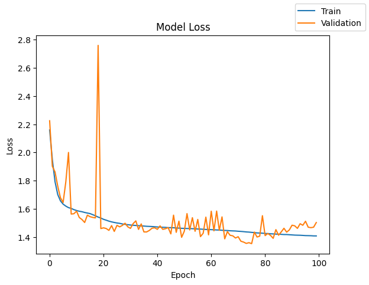

```python
plot(history_4,'loss')
```

**Recall**

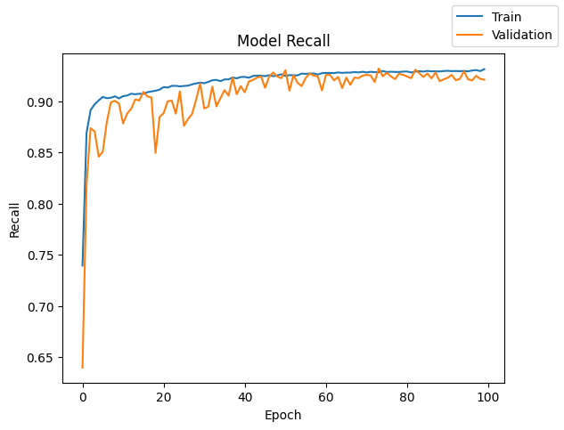

```python
plot(history_4,'recall')
```

```python
model_4_train_perf = model_performance_classification(model_4, X_train, y_train_en)
model_4_train_perf
```

```
1313/1313 ━━━━━━━━━━━━━━━━━━━━ 2s 1ms/step
```

|  | Accuracy | Recall | Precision | F1 Score |
| --- | --- | --- | --- | --- |
| 0 | 0.604333 | 0.604333 | 0.614199 | 0.603534 |

```python
model_4_test_perf = model_performance_classification(model_4, X_test, y_test_en)
model_4_test_perf
```

```
563/563 ━━━━━━━━━━━━━━━━━━━━ 1s 1ms/step
```

|  | Accuracy | Recall | Precision | F1 Score |
| --- | --- | --- | --- | --- |
| 0 | 0.587 | 0.587 | 0.596056 | 0.586018 |

```python
save_recall_score(model_4, "NN with Batch Normalization")
```

```
1313/1313 ━━━━━━━━━━━━━━━━━━━━ 2s 1ms/step
563/563 ━━━━━━━━━━━━━━━━━━━━ 1s 1ms/step
```

**Classification Reports**

```python
## Predict Model on X_train
y_pred4 = model_4.predict(X_train)

## Predict y_pred3 using argmax
y_pred4_argmax = np.argmax(y_pred4, axis=1)

## Classification report for train data
cr = metrics.classification_report(y_train_true_argmax, y_pred4_argmax)
print(cr)
```

```
1313/1313 ━━━━━━━━━━━━━━━━━━━━ 3s 2ms/step
              precision    recall  f1-score   support

           0       0.73      0.61      0.67      4186
           1       0.60      0.66      0.63      4172
           2       0.57      0.43      0.49      4197
           3       0.51      0.69      0.59      4281
           4       0.78      0.72      0.75      4188
           5       0.50      0.62      0.55      4232
           6       0.71      0.53      0.61      4168
           7       0.59      0.71      0.65      4192
           8       0.54      0.46      0.50      4188
           9       0.61      0.62      0.61      4196

    accuracy                           0.60     42000
   macro avg       0.61      0.60      0.60     42000
weighted avg       0.61      0.60      0.60     42000
```

```python
## Predict Model on X_test
y_pred4 = model_4.predict(X_test)

## Predict y_pred4 using argmax
y_pred4_argmax = np.argmax(y_pred4, axis=1)

## Classification report for test data on y_test_true_argmax and y_pred4_argmax
cr = metrics.classification_report(y_test_true_argmax, y_pred4_argmax)
print(cr)
```

```
563/563 ━━━━━━━━━━━━━━━━━━━━ 1s 1ms/step
              precision    recall  f1-score   support

           0       0.70      0.60      0.65      1814
           1       0.60      0.65      0.62      1828
           2       0.54      0.38      0.45      1803
           3       0.48      0.68      0.56      1719
           4       0.76      0.71      0.73      1812
           5       0.49      0.60      0.54      1768
           6       0.69      0.55      0.61      1832
           7       0.57      0.68      0.62      1808
           8       0.53      0.45      0.49      1812
           9       0.58      0.58      0.58      1804

    accuracy                           0.59     18000
   macro avg       0.60      0.59      0.59     18000
weighted avg       0.60      0.59      0.59     18000
```

**Confusion Matrix**

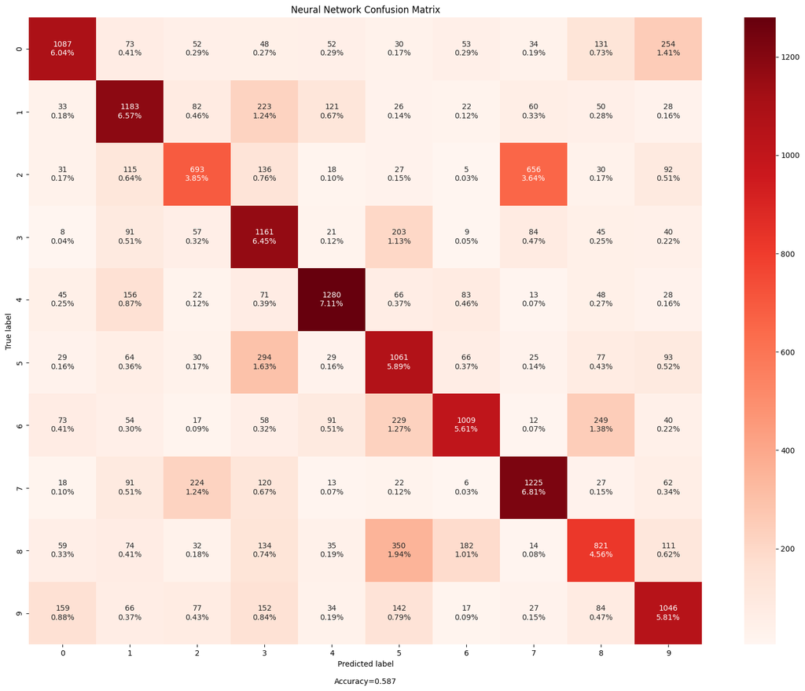

```python
## Plot Confusion Matrix
cm4 = confusion_matrix(y_test_true_argmax, y_pred4_argmax)
make_confusion_matrix(cm4, cmap='Reds', title='Neural Network Confusion Matrix')
plt.show()
```

## Model Improvement: NN Model with Dropout for regularization and weights using He normal

```python
BackendClearSession()
```

```python
#Initializing the neural network
model_5 = Sequential()

## Add input layer with 32 neurons and relu as activation function
model_5.add(Dense(32, activation='relu', kernel_initializer="he_normal", input_dim = X_train.shape[1]))

## Add dropout with dropout_rate= 0.4
model_5.add(Dropout(0.4))
## Add Hiden layer with 16 neurons and relu as activation function
model_5.add(Dense(16, activation='relu', kernel_initializer="he_normal"))

## Add dropout with dropout_rate= 0.2
model_5.add(Dropout(0.2))
## Add Hiden layer with 8 neurons and relu as activation function
model_5.add(Dense(8, activation='relu', kernel_initializer="he_normal"))

## Add Output layer with sigmoid as activation function with 10 neurons (Predicting 10 classes)
model_5.add(Dense(10, activation = 'sigmoid' , kernel_initializer="he_normal"))
```

```python
model_5.summary()
```

```
Model: "sequential"
```

```
┏━━━━━━━━━━━━━━━━━━━━━━━━━━━━━━━━━┳━━━━━━━━━━━━━━━━━━━━━━━━┳━━━━━━━━━━━━━━━┓
┃ Layer (type)                    ┃ Output Shape           ┃       Param # ┃
┡━━━━━━━━━━━━━━━━━━━━━━━━━━━━━━━━━╇━━━━━━━━━━━━━━━━━━━━━━━━╇━━━━━━━━━━━━━━━┩
│ dense (Dense)                   │ (None, 32)             │        32,800 │
├─────────────────────────────────┼────────────────────────┼───────────────┤
│ dropout (Dropout)               │ (None, 32)             │             0 │
├─────────────────────────────────┼────────────────────────┼───────────────┤
│ dense_1 (Dense)                 │ (None, 16)             │           528 │
├─────────────────────────────────┼────────────────────────┼───────────────┤
│ dropout_1 (Dropout)             │ (None, 16)             │             0 │
├─────────────────────────────────┼────────────────────────┼───────────────┤
│ dense_2 (Dense)                 │ (None, 8)              │           136 │
├─────────────────────────────────┼────────────────────────┼───────────────┤
│ dense_3 (Dense)                 │ (None, 10)             │            90 │
└─────────────────────────────────┴────────────────────────┴───────────────┘
```

```
 Total params: 33,554 (131.07 KB)
```

```
 Trainable params: 33,554 (131.07 KB)
```

```
 Non-trainable params: 0 (0.00 B)
```

```python
# Defining Adam as the optimizer to be used
optimizer = tf.keras.optimizers.Adam()

## Compile Model with categorical cross entropy as loss function
model_5.compile(loss='categorical_crossentropy', optimizer=optimizer, metrics=['accuracy', 'recall'])
```

```python
## Fit Model on X_train and y_train_en data for 100 epochs
start = time.time()
history_5 = model_5.fit(X_train, y_train_en, validation_split=0.2, epochs=epochs, batch_size=batch_size, verbose=1)
end = time.time()
```

```
1050/1050 ━━━━━━━━━━━━━━━━━━━━ 7s 5ms/step - accuracy: 0.0993 - loss: 2.3098 - recall: 0.5296 - val_accuracy: 0.0974 - val_loss: 2.3029 - val_recall: 0.3968
1050/1050 ━━━━━━━━━━━━━━━━━━━━ 5s 4ms/step - accuracy: 0.0989 - loss: 2.3028 - recall: 0.4345 - val_accuracy: 0.0974 - val_loss: 2.3030 - val_recall: 0.3968
1050/1050 ━━━━━━━━━━━━━━━━━━━━ 4s 4ms/step - accuracy: 0.0996 - loss: 2.3029 - recall: 0.4290 - val_accuracy: 0.0974 - val_loss: 2.3030 - val_recall: 0.2954
1050/1050 ━━━━━━━━━━━━━━━━━━━━ 5s 5ms/step - accuracy: 0.0996 - loss: 2.3029 - recall: 0.4265 - val_accuracy: 0.0974 - val_loss: 2.3030 - val_recall: 0.2954
1050/1050 ━━━━━━━━━━━━━━━━━━━━ 5s 5ms/step - accuracy: 0.0996 - loss: 2.3029 - recall: 0.4249 - val_accuracy: 0.0974 - val_loss: 2.3030 - val_recall: 0.2954
1050/1050 ━━━━━━━━━━━━━━━━━━━━ 4s 4ms/step - accuracy: 0.0996 - loss: 2.3029 - recall: 0.4243 - val_accuracy: 0.0974 - val_loss: 2.3030 - val_recall: 0.2954
1050/1050 ━━━━━━━━━━━━━━━━━━━━ 5s 5ms/step - accuracy: 0.0996 - loss: 2.3029 - recall: 0.4232 - val_accuracy: 0.0974 - val_loss: 2.3030 - val_recall: 0.2954
1050/1050 ━━━━━━━━━━━━━━━━━━━━ 5s 4ms/step - accuracy: 0.0996 - loss: 2.3029 - recall: 0.4216 - val_accuracy: 0.0974 - val_loss: 2.3030 - val_recall: 0.2954
1050/1050 ━━━━━━━━━━━━━━━━━━━━ 4s 4ms/step - accuracy: 0.0996 - loss: 2.3029 - recall: 0.4198 - val_accuracy: 0.0974 - val_loss: 2.3030 - val_recall: 0.2954
1050/1050 ━━━━━━━━━━━━━━━━━━━━ 7s 6ms/step - accuracy: 0.0996 - loss: 2.3029 - recall: 0.4185 - val_accuracy: 0.0974 - val_loss: 2.3030 - val_recall: 0.2954
1050/1050 ━━━━━━━━━━━━━━━━━━━━ 4s 4ms/step - accuracy: 0.0996 - loss: 2.3029 - recall: 0.4171 - val_accuracy: 0.0974 - val_loss: 2.3030 - val_recall: 0.2954
1050/1050 ━━━━━━━━━━━━━━━━━━━━ 5s 4ms/step - accuracy: 0.0996 - loss: 2.3029 - recall: 0.4152 - val_accuracy: 0.0974 - val_loss: 2.3030 - val_recall: 0.2954
1050/1050 ━━━━━━━━━━━━━━━━━━━━ 6s 5ms/step - accuracy: 0.0996 - loss: 2.3029 - recall: 0.4129 - val_accuracy: 0.0974 - val_loss: 2.3030 - val_recall: 0.2954
1050/1050 ━━━━━━━━━━━━━━━━━━━━ 4s 4ms/step - accuracy: 0.0996 - loss: 2.3029 - recall: 0.4119 - val_accuracy: 0.0974 - val_loss: 2.3030 - val_recall: 0.2954
1050/1050 ━━━━━━━━━━━━━━━━━━━━ 4s 4ms/step - accuracy: 0.0996 - loss: 2.3029 - recall: 0.4100 - val_accuracy: 0.0974 - val_loss: 2.3030 - val_recall: 0.2954
1050/1050 ━━━━━━━━━━━━━━━━━━━━ 6s 5ms/step - accuracy: 0.0996 - loss: 2.3029 - recall: 0.4092 - val_accuracy: 0.0974 - val_loss: 2.3030 - val_recall: 0.2954
1050/1050 ━━━━━━━━━━━━━━━━━━━━ 4s 4ms/step - accuracy: 0.0996 - loss: 2.3029 - recall: 0.4075 - val_accuracy: 0.0974 - val_loss: 2.3030 - val_recall: 0.2954
1050/1050 ━━━━━━━━━━━━━━━━━━━━ 6s 5ms/step - accuracy: 0.0996 - loss: 2.3029 - recall: 0.4060 - val_accuracy: 0.0974 - val_loss: 2.3030 - val_recall: 0.2954
1050/1050 ━━━━━━━━━━━━━━━━━━━━ 4s 4ms/step - accuracy: 0.0996 - loss: 2.3029 - recall: 0.4052 - val_accuracy: 0.0974 - val_loss: 2.3030 - val_recall: 0.2954
1050/1050 ━━━━━━━━━━━━━━━━━━━━ 4s 4ms/step - accuracy: 0.0996 - loss: 2.3029 - recall: 0.4019 - val_accuracy: 0.0974 - val_loss: 2.3030 - val_recall: 0.2954
1050/1050 ━━━━━━━━━━━━━━━━━━━━ 5s 5ms/step - accuracy: 0.0996 - loss: 2.3029 - recall: 0.4007 - val_accuracy: 0.0974 - val_loss: 2.3030 - val_recall: 0.2954
1050/1050 ━━━━━━━━━━━━━━━━━━━━ 4s 4ms/step - accuracy: 0.0996 - loss: 2.3029 - recall: 0.3979 - val_accuracy: 0.0974 - val_loss: 2.3030 - val_recall: 0.2954
1050/1050 ━━━━━━━━━━━━━━━━━━━━ 5s 4ms/step - accuracy: 0.0996 - loss: 2.3029 - recall: 0.3967 - val_accuracy: 0.0974 - val_loss: 2.3030 - val_recall: 0.2954
1050/1050 ━━━━━━━━━━━━━━━━━━━━ 6s 5ms/step - accuracy: 0.0996 - loss: 2.3029 - recall: 0.3965 - val_accuracy: 0.0974 - val_loss: 2.3030 - val_recall: 0.2954
1050/1050 ━━━━━━━━━━━━━━━━━━━━ 4s 4ms/step - accuracy: 0.0996 - loss: 2.3029 - recall: 0.3946 - val_accuracy: 0.0974 - val_loss: 2.3030 - val_recall: 0.2954
1050/1050 ━━━━━━━━━━━━━━━━━━━━ 4s 4ms/step - accuracy: 0.0996 - loss: 2.3029 - recall: 0.3931 - val_accuracy: 0.0974 - val_loss: 2.3030 - val_recall: 0.2954
```

[output cut: 74 more lines]

```python
print("Time taken in seconds ",end-start)
```

```
Time taken in seconds  546.9294376373291
```

**Loss Function**

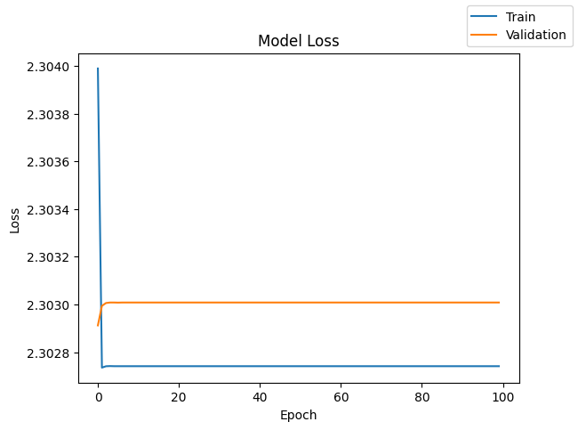

```python
plot(history_5,'loss')
```

**Recall**

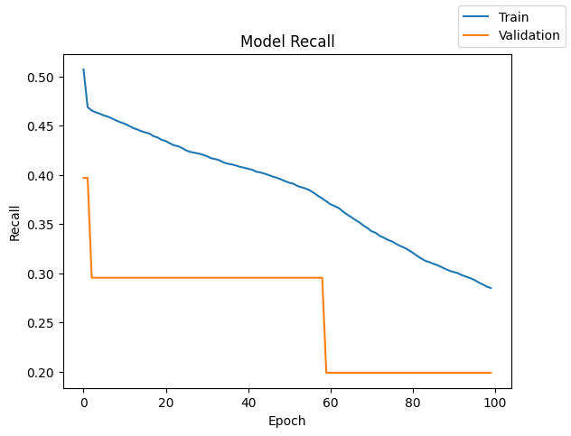

```python
plot(history_5,'recall')
```

```python
model_5_train_perf = model_performance_classification(model_5, X_train, y_train_en)
model_5_train_perf
```

```
1313/1313 ━━━━━━━━━━━━━━━━━━━━ 2s 2ms/step
```

|  | Accuracy | Recall | Precision | F1 Score |
| --- | --- | --- | --- | --- |
| 0 | 0.100762 | 0.100762 | 0.010153 | 0.018447 |

```python
model_5_test_perf = model_performance_classification(model_5, X_test, y_test_en)
model_5_test_perf
```

```
563/563 ━━━━━━━━━━━━━━━━━━━━ 1s 2ms/step
```

|  | Accuracy | Recall | Precision | F1 Score |
| --- | --- | --- | --- | --- |
| 0 | 0.098222 | 0.098222 | 0.009648 | 0.017569 |

```python
save_recall_score(model_5, "NN with Dropout and He initialization")
```

```
1313/1313 ━━━━━━━━━━━━━━━━━━━━ 2s 1ms/step
563/563 ━━━━━━━━━━━━━━━━━━━━ 1s 1ms/step
```

**Classification Reports**

```python
## Predict Model on X_train
y_pred5 = model_5.predict(X_train)

## Predict y_pred3 using argmax
y_pred5_argmax = np.argmax(y_pred5, axis=1)

## Classification report for train data
cr = metrics.classification_report(y_train_true_argmax, y_pred5_argmax)
print(cr)
```

```
1313/1313 ━━━━━━━━━━━━━━━━━━━━ 2s 2ms/step
              precision    recall  f1-score   support

           0       0.00      0.00      0.00      4186
           1       0.00      0.00      0.00      4172
           2       0.00      0.00      0.00      4197
           3       0.00      0.00      0.00      4281
           4       0.00      0.00      0.00      4188
           5       0.10      1.00      0.18      4232
           6       0.00      0.00      0.00      4168
           7       0.00      0.00      0.00      4192
           8       0.00      0.00      0.00      4188
           9       0.00      0.00      0.00      4196

    accuracy                           0.10     42000
   macro avg       0.01      0.10      0.02     42000
weighted avg       0.01      0.10      0.02     42000
```

```python
## Predict Model on X_test
y_pred5 = model_5.predict(X_test)

## Predict y_pred4 using argmax
y_pred5_argmax = np.argmax(y_pred5, axis=1)

## Classification report for test data on y_test_true_argmax and y_pred5_argmax
cr = metrics.classification_report(y_test_true_argmax, y_pred5_argmax)
print(cr)
```

```
563/563 ━━━━━━━━━━━━━━━━━━━━ 1s 2ms/step
              precision    recall  f1-score   support

           0       0.00      0.00      0.00      1814
           1       0.00      0.00      0.00      1828
           2       0.00      0.00      0.00      1803
           3       0.00      0.00      0.00      1719
           4       0.00      0.00      0.00      1812
           5       0.10      1.00      0.18      1768
           6       0.00      0.00      0.00      1832
           7       0.00      0.00      0.00      1808
           8       0.00      0.00      0.00      1812
           9       0.00      0.00      0.00      1804

    accuracy                           0.10     18000
   macro avg       0.01      0.10      0.02     18000
weighted avg       0.01      0.10      0.02     18000
```

**Confusion Matrix**

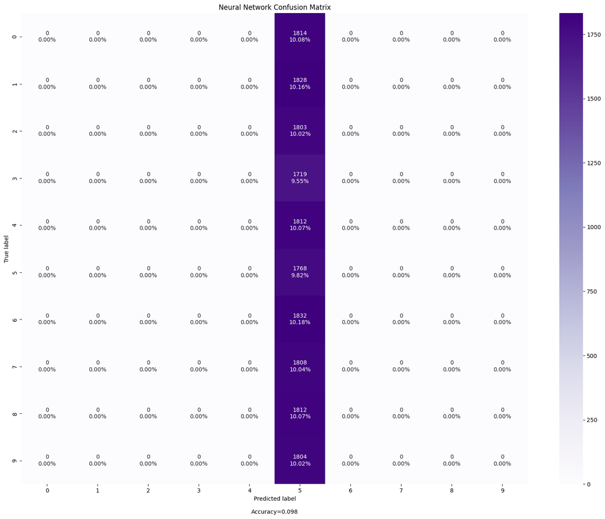

```python
## Plot Confusion Matrix
cm5 = confusion_matrix(y_test_true_argmax, y_pred5_argmax)
make_confusion_matrix(cm5, cmap='Purples', title='Neural Network Confusion Matrix')
plt.show()
```

## Model Performance Comparision and Final Model selection

```python
print("Training performance comparison")
train_metric_df
```

```
Training performance comparison
```

|  | recall |
| --- | --- |
| NN with Adam and He initialization | 0.829929 |
| NN with Adam 0.01 | 0.737476 |
| NN with Dropout | 0.100762 |
| NN with Batch Normalization | 0.604333 |
| NN with Dropout and He initialization | 0.100762 |

```python
print("Test performance comparison")
test_metric_df
```

```
Test performance comparison
```

|  | recall |
| --- | --- |
| NN with Adam and He initialization | 0.775611 |
| NN with Adam 0.01 | 0.729389 |
| NN with Dropout | 0.098222 |
| NN with Batch Normalization | 0.587000 |
| NN with Dropout and He initialization | 0.098222 |

```python
# training performance comparison

models_train_comp_df = pd.concat(
    [
        model_train_perf.T,
        model_2_train_perf.T,
        model_3_train_perf.T,
        model_4_train_perf.T,
        model_5_train_perf.T
    ],
    axis=1
)
models_train_comp_df.columns = [
    "NN (Adam, He initialization)",
    "NN (Adam [0.01])",
    "NN (Adam,  dropout[0.2, 0.1])",
    "NN (Adam, Batch Normalization)",
    "NN (Adam, dropout[0.4, 0.2], He initialization)"
]
```

```python
# test data performance comparison

models_test_comp_df = pd.concat(
    [
        model_test_perf.T,
        model_2_test_perf.T,
        model_3_test_perf.T,
        model_4_test_perf.T,
        model_5_test_perf.T
    ],
    axis=1
)
models_test_comp_df.columns = [
    "NN (Adam, He initialization)",
    "NN (Adam [0.01])",
    "NN (Adam,  dropout[0.2, 0.1])",
    "NN (Adam, Batch Normalization)",
    "NN (Adam, dropout[0.4, 0.2], He initialization)"
]
```

```python
models_train_comp_df
```

|  | NN (Adam, He initialization) | NN (Adam [0.01]) | NN (Adam, dropout[0.2, 0.1]) | NN (Adam, Batch Normalization) | NN (Adam, dropout[0.4, 0.2], He initialization) |
| --- | --- | --- | --- | --- | --- |
| Accuracy | 0.829929 | 0.737476 | 0.100762 | 0.604333 | 0.100762 |
| Recall | 0.829929 | 0.737476 | 0.100762 | 0.604333 | 0.100762 |
| Precision | 0.833230 | 0.740637 | 0.010153 | 0.614199 | 0.010153 |
| F1 Score | 0.830265 | 0.737638 | 0.018447 | 0.603534 | 0.018447 |

```python
models_test_comp_df
```

|  | NN (Adam, He initialization) | NN (Adam [0.01]) | NN (Adam, dropout[0.2, 0.1]) | NN (Adam, Batch Normalization) | NN (Adam, dropout[0.4, 0.2], He initialization) |
| --- | --- | --- | --- | --- | --- |
| Accuracy | 0.775611 | 0.729389 | 0.098222 | 0.587000 | 0.098222 |
| Recall | 0.775611 | 0.729389 | 0.098222 | 0.587000 | 0.098222 |
| Precision | 0.778800 | 0.732522 | 0.009648 | 0.596056 | 0.009648 |
| F1 Score | 0.775934 | 0.729467 | 0.017569 | 0.586018 | 0.017569 |

```python
models_train_comp_df.loc["F1 Score"] - models_test_comp_df.loc["F1 Score"]
```

|  | F1 Score |
| --- | --- |
| NN (Adam, He initialization) | 0.054330 |
| NN (Adam [0.01]) | 0.008171 |
| NN (Adam, dropout[0.2, 0.1]) | 0.000878 |
| NN (Adam, Batch Normalization) | 0.017516 |
| NN (Adam, dropout[0.4, 0.2], He initialization) | 0.000878 |

**dtype:** float64

*Final Model: NN (Adam, He initialization)

Reasoning:

- Best F1 score on the training set (0.83), indicating strong performance in learning from the training data.
- Best F1 score on the test set (0.78), demonstrating good performance in generalizing to unseen data.
- When considering test scores only, Model 1 outperforms others, suggesting its effectiveness in real-world applications and new data scenarios.*

## **Actionable Insights and Business Recommendations**

### **🔍Insights from Analysis**

**Location-aware Digit Patterns**

In real-world scenarios, certain digit patterns correlate with geographic regions (e.g., U.S. ZIP codes or street numbering systems).

Although SVHN doesn't provide GPS labels, combining its outputs with geo-tagged data could support geo-contextual modeling.

### **📈 Business Recommendations**

**Enhance Geolocation Accuracy for Mapping Services**

Integrate a model trained on SVHN into Google Maps or Waze to improve address resolution, especially in areas with poor address labeling or low-resolution imagery.

**Automate Property Cataloging for Real Estate Platforms**

Use digit detection to auto-tag properties with street numbers, accelerating the cataloging of real estate listings and reducing manual effort in verifying property addresses.

**Improve Delivery Logistics for E-commerce and Courier Services**

Partner with delivery companies (e.g., FedEx, Amazon) to provide digit recognition APIs that identify house numbers from delivery driver's street-view footage in real time.

**Aid in Urban Planning and Infrastructure Audits**

Governments and urban planners can use models trained on SVHN for address verification, helping in census activities, infrastructure monitoring, or property tax audits.

**Enable Smart City Navigation Features**

Integrate number-recognition models into autonomous vehicles or smart glasses to help them locate buildings more precisely using street-facing cameras.

**Support Accessibility Innovations**

Digit recognition can be embedded into assistive devices for the visually impaired, enabling them to recognize and be alerted to house numbers as they navigate neighborhoods.

**Extend the Dataset with Contextual Metadata**

Business opportunity exists in extending SVHN-like datasets with contextual information (e.g., GPS, time of day, weather), opening the door for context-aware AI systems.

**✅ Summary**

The SVHN dataset provides an excellent real-world testbed for digit recognition under diverse and challenging conditions. Businesses across mapping, logistics, real estate, urban planning, and accessibility tech can leverage trained models to automate and enhance geolocation services. Improving dataset annotations (e.g., house number sequences or GPS tagging) would further unlock valuable commercial applications.